# Assignment 1: Task 2

Jessica Jagdeo

2/2/2020

Environmental and climatic variables for a range of countries have been obtained from publicly available remote sensing datasets and published on the Google Earth Engine platform (zander_venter, Kaggle). This project explores the potential associations between the country-level environmental and climatic variables through a principal components analysis. The goal is to determine if there are any associations between countries’ accessibility to cities, elevation, and mean annual temperature and precipitation.

#### 1. Load necessary packages.

```r
library(tidyverse)
library(janitor)
library(kableExtra)
library(naniar)
library(skimr)
library(sf)
library(tmap)
library(ggfortify)
```

#### 2. Read in the data: Country-level environmental and climatic variables from zander_venter on Kaggle.

```r
# I am interested in associations between a country's accessiblity to cities, elevation, average annual rainfall, and average annual temperature, so I will simplify the raw data set to contain only these variables

env_var <- read_csv("world_env_vars.csv")

env_simplified <- env_var %>%
  clean_names() %>%
  select(country, accessibility_to_cities, elevation, temp_mean_annual, rain_mean_annual)
```

#### 3. Simplify the data for PCA analysis.

```r
# Check out NAs within the simplified data frame to assess missing data points

summary(env_simplified)
```

```
##    country          accessibility_to_cities   elevation
##  Length:243         Min.   :    0.969       Min.   :   0.0
##  Class :character   1st Qu.:   73.534       1st Qu.: 110.6
##  Mode  :character   Median :  214.508       Median : 301.4
##                     Mean   :  911.394       Mean   : 475.7
##                     3rd Qu.:  625.937       3rd Qu.: 598.9
##                     Max.   :15531.333       Max.   :5428.8
##                     NA's   :5               NA's   :6
##  temp_mean_annual rain_mean_annual
##  Min.   :-17.21   Min.   :  14.16
##  1st Qu.: 10.75   1st Qu.: 587.12
##  Median : 22.25   Median :1043.14
##  Mean   : 18.47   Mean   :1231.09
##  3rd Qu.: 25.52   3rd Qu.:1785.77
##  Max.   : 28.26   Max.   :4547.62
##  NA's   :6        NA's   :5
```

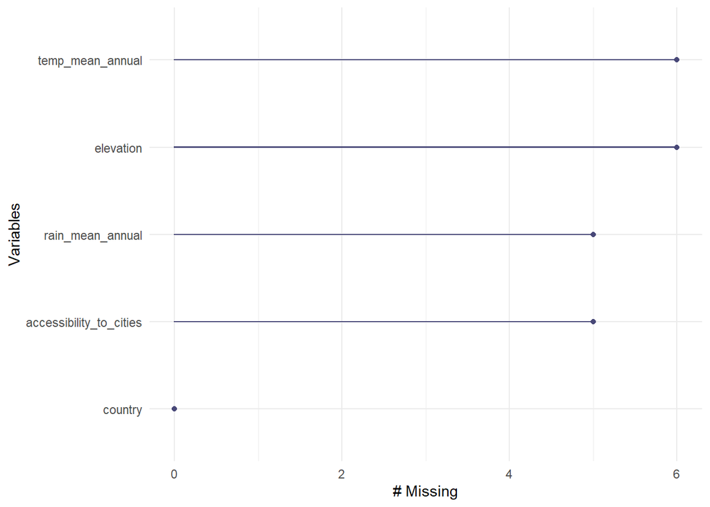

```r
gg_miss_var(env_simplified)
```

```r
# There are missing data points, but not many compared to the actual scope of the data (10 out of 243 observations), so I will retain only complete observations
```

```r
# Using drop_na() to remove observations that contain at least 1 NA from simplified data set

env_simp_nona <- env_simplified %>%
  drop_na() %>%
  select(-country) %>%
  rename("Accessibility to Cities" = accessibility_to_cities, "Elevation" = elevation, "Mean Annual Temperature" = temp_mean_annual, "Mean Annual Precipitation" = rain_mean_annual)

summary(env_simp_nona) # Recheck for NAs
```

```
##  Accessibility to Cities   Elevation        Mean Annual Temperature
##  Min.   :    0.969       Min.   :   0.226   Min.   :-8.345
##  1st Qu.:   71.875       1st Qu.: 115.205   1st Qu.:11.288
##  Median :  212.293       Median : 302.308   Median :22.473
##  Mean   :  807.247       Mean   : 483.708   Mean   :18.810
##  3rd Qu.:  566.193       3rd Qu.: 600.242   3rd Qu.:25.559
##  Max.   :12517.768       Max.   :5428.765   Max.   :28.257
##  Mean Annual Precipitation
##  Min.   :  14.16
##  1st Qu.: 585.36
##  Median :1038.97
##  Mean   :1234.90
##  3rd Qu.:1788.88
##  Max.   :4547.62
```

#### 4. Conduct a Principal Components Analysis.

```r
# Principal Components Analysis

env_var_pca <- prcomp(env_simp_nona, scale = TRUE)

summary(env_var_pca)
```

```
## Importance of components:
##                           PC1    PC2    PC3    PC4
## Standard deviation     1.3168 1.0034 0.8736 0.7043
## Proportion of Variance 0.4335 0.2517 0.1908 0.1240
## Cumulative Proportion  0.4335 0.6852 0.8760 1.0000
```

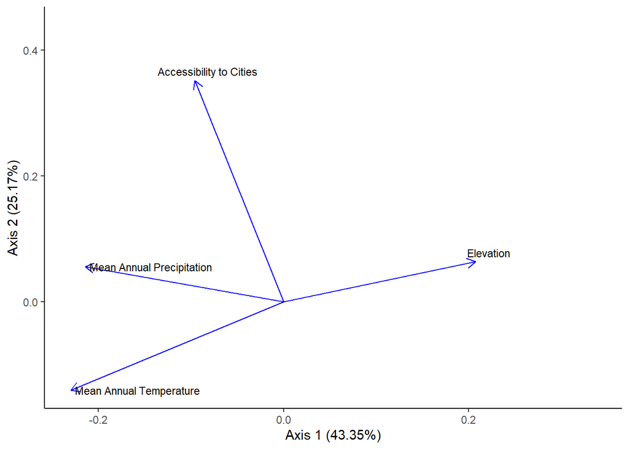

```r
# Plot PCA results to visualize associations

env_var_biplot <- autoplot(env_var_pca,
                      colour = "NA",
                      loadings.colour = "blue",
                      loadings.label = TRUE,
                      loadings.label.size = 3,
                      loadings.label.colour = "black",
                      loadings.label.repel = TRUE) +
                      theme_classic() +
                      labs(x = "Axis 1 (43.35%)",
                           y = "Axis 2 (25.17%)")


env_var_biplot
```

```r
# Biplot captures about 68% of variance
```

**Figure 1. Principal components analysis biplot showing the associations between environmental and climatic variables at the country-level.** Variables depicted by this biplot include accessiblity to cities, mean annual precipitation, mean annual temperature, and elevation. Data source: zander_venter, Kaggle.

To summarize key observations from Figure 1:

1. There is no correlation between accessibility to cities and elevation.
2. There is also no correlation between accessibility to cities and mean annual temperature.
3. There is a negative correlation between elevation and mean annual temperature, so as elevation increases, mean annual temperature decreases and vice versa.